# Case Study 1 DDS 6306

Cameron Stewart and Adam Alidra

2/14/2021

## Read in Data

```r
library(naniar)
library(stringr)
library(class)
library(caret)
library(e1071)
library(plyr)
library(dplyr)
library(ggthemes)
library(tidyverse)
#Read in beers.csv and convert variables to the appropriate class. Also change the 'Name' column to be more specific due to conflict in the other dataset

beers = read.csv("~/Documents/SMU_DS/Doing Data Science/DDS_Git/Doing-Data-Science/Unit 8 and 9 Case Study 1/Beers.csv",header = TRUE)

#beers = read.csv('/Users/adalidra/Desktop/Data Science Program/DS6306/MSDS_6306_Doing-Data-Science/Unit 8 and 9 Case Study 1/Beers.csv',header = TRUE)

colnames(beers)[1]="Beer_Name"
beers$Beer_ID = as.factor(beers$Beer_ID)
beers$Brewery_id = as.factor(beers$Brewery_id)
beers$Style = as.factor(beers$Style)
summary(beers)
```

```
##   Beer_Name            Beer_ID          ABV               IBU
##  Length:2410        1      :   1   Min.   :0.00100   Min.   :  4.00
##  Class :character   4      :   1   1st Qu.:0.05000   1st Qu.: 21.00
##  Mode  :character   5      :   1   Median :0.05600   Median : 35.00
##                     6      :   1   Mean   :0.05977   Mean   : 42.71
##                     7      :   1   3rd Qu.:0.06700   3rd Qu.: 64.00
##                     8      :   1   Max.   :0.12800   Max.   :138.00
##                     (Other):2404   NA's   :62        NA's   :1005
##    Brewery_id                              Style          Ounces
##  11     :  62   American IPA                  : 424   Min.   : 8.40
##  26     :  38   American Pale Ale (APA)       : 245   1st Qu.:12.00
##  167    :  33   American Amber / Red Ale      : 133   Median :12.00
##  142    :  25   American Blonde Ale           : 108   Mean   :13.59
##  47     :  24   American Double / Imperial IPA: 105   3rd Qu.:16.00
##  81     :  23   American Pale Wheat Ale       :  97   Max.   :32.00
##  (Other):2205   (Other)                       :1298
```

```r
str(beers)
```

```
## 'data.frame':    2410 obs. of  7 variables:
##  $ Beer_Name : chr  "Pub Beer" "Devil's Cup" "Rise of the Phoenix" "Sinister" ...
##  $ Beer_ID   : Factor w/ 2410 levels "1","4","5","6",..: 1188 1988 1987 1986 1985 1984 1983 1982 1981 1860 ...
##  $ ABV       : num  0.05 0.066 0.071 0.09 0.075 0.077 0.045 0.065 0.055 0.086 ...
##  $ IBU       : int  NA NA NA NA NA NA NA NA NA NA ...
##  $ Brewery_id: Factor w/ 558 levels "1","2","3","4",..: 409 178 178 178 178 178 178 178 178 178 ...
##  $ Style     : Factor w/ 100 levels "","Abbey Single Ale",..: 19 18 16 12 16 80 18 22 18 12 ...
##  $ Ounces    : num  12 12 12 12 12 12 12 12 12 12 ...
```

```r
#Read in breweries.csv and convert variables to the appropriate class. Also change the 'Name' column to be more specific due to conflict with the other dataset

breweries = read.csv("~/Documents/SMU_DS/Doing Data Science/DDS_Git/Doing-Data-Science/Unit 8 and 9 Case Study 1/Breweries.csv",header = TRUE)

#breweries = read.csv('/Users/adalidra/Desktop/Data Science Program/DS6306/MSDS_6306_Doing-Data-Science/Unit 8 and 9 Case Study 1/Breweries.csv',header = TRUE)

colnames(breweries)[2] = "Brewery_Name"
breweries$Brew_ID = as.factor(breweries$Brew_ID)
breweries$City = as.factor(breweries$City)
breweries$State = as.factor(breweries$State)
str(breweries)
```

```
## 'data.frame':    558 obs. of  4 variables:
##  $ Brew_ID     : Factor w/ 558 levels "1","2","3","4",..: 1 2 3 4 5 6 7 8 9 10 ...
##  $ Brewery_Name: chr  "NorthGate Brewing " "Against the Grain Brewery" "Jack's Abby Craft Lagers" "Mike Hess Brewing Company" ...
##  $ City        : Factor w/ 384 levels "Abingdon","Abita Springs",..: 228 200 122 299 300 62 91 48 152 136 ...
##  $ State       : Factor w/ 51 levels " AK"," AL"," AR",..: 24 18 20 5 5 41 6 23 23 23 ...
```

## Find the numer of Breweries located in each state

```r
breweries_by_state = data.frame(breweries %>% group_by(State) %>% summarise(Count = n()) %>% arrange(desc(Count)))
breweries_by_state
```

```
##    State Count
## 1     CO    47
## 2     CA    39
## 3     MI    32
## 4     OR    29
## 5     TX    28
## 6     PA    25
## 7     MA    23
## 8     WA    23
## 9     IN    22
## 10    WI    20
## 11    NC    19
## 12    IL    18
## 13    NY    16
## 14    VA    16
```

[output cut: 37 more lines]

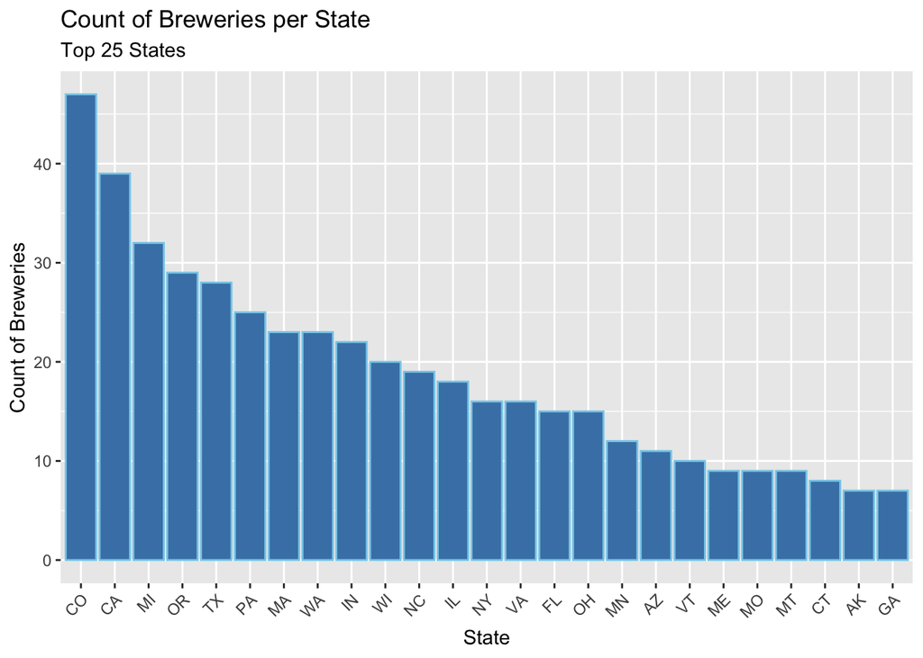

```r
breweries_by_state$State= fct_reorder(breweries_by_state$State, desc(breweries_by_state$Count))

head(breweries_by_state,25) %>% ggplot(aes(x=reorder(State,-Count),y=Count))+geom_bar(stat = 'identity',color='skyblue',fill='steelblue') + xlab("State") + ylab("Count of Breweries") + ggtitle("Count of Breweries per State","Top 25 States") + theme(axis.text.x=element_text(angle=45, hjust=1))
```

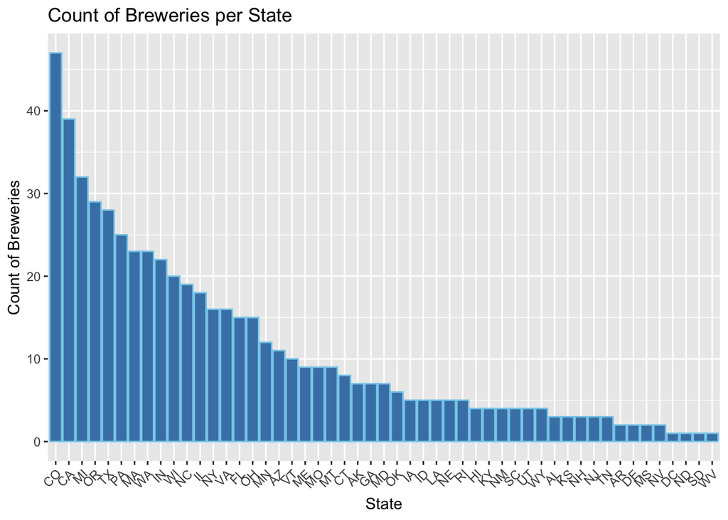

```r
#Adding combined chart of all 51 states (doesn't output in knit file well)
breweries_by_state %>% ggplot(aes(x=reorder(State,-Count),y=Count))+geom_bar(stat = 'identity',color='skyblue',fill='steelblue') + xlab("State") + ylab("Count of Breweries") + ggtitle("Count of Breweries per State") + theme(axis.text.x=element_text(angle=45, hjust=1))
```

## Merge beer data with the breweries data. Printing the first 6 observations and the last 6 observations to check the merged file.

```r
#Performed outer merge

beers_merge=merge(beers,breweries,by.x = "Brewery_id", by.y = "Brew_ID")
str(beers_merge)
```

```
## 'data.frame':    2410 obs. of  10 variables:
##  $ Brewery_id  : Factor w/ 558 levels "1","2","3","4",..: 1 1 1 1 1 1 10 100 101 101 ...
##  $ Beer_Name   : chr  "Get Together" "Maggie's Leap" "Wall's End" "Pumpion" ...
##  $ Beer_ID     : Factor w/ 2410 levels "1","4","5","6",..: 2410 2409 2408 2407 2406 2405 2359 2161 2160 2078 ...
##  $ ABV         : num  0.045 0.049 0.048 0.06 0.06 0.056 0.052 0.089 0.09 0.07 ...
##  $ IBU         : int  50 26 19 38 25 47 NA 126 NA NA ...
##  $ Style       : Factor w/ 100 levels "","Abbey Single Ale",..: 16 77 48 83 22 57 18 12 66 22 ...
##  $ Ounces      : num  16 16 16 16 16 16 16 12 12 12 ...
##  $ Brewery_Name: chr  "NorthGate Brewing " "NorthGate Brewing " "NorthGate Brewing " "NorthGate Brewing " ...
##  $ City        : Factor w/ 384 levels "Abingdon","Abita Springs",..: 228 228 228 228 228 228 136 71 192 192 ...
##  $ State       : Factor w/ 51 levels " AK"," AL"," AR",..: 24 24 24 24 24 24 23 36 18 18 ...
```

```r
head(beers_merge,6)
```

```
##   Brewery_id     Beer_Name Beer_ID   ABV IBU
## 1          1  Get Together    2692 0.045  50
## 2          1 Maggie's Leap    2691 0.049  26
## 3          1    Wall's End    2690 0.048  19
## 4          1       Pumpion    2689 0.060  38
## 5          1    Stronghold    2688 0.060  25
## 6          1   Parapet ESB    2687 0.056  47
##                                 Style Ounces       Brewery_Name        City
## 1                        American IPA     16 NorthGate Brewing  Minneapolis
## 2                  Milk / Sweet Stout     16 NorthGate Brewing  Minneapolis
## 3                   English Brown Ale     16 NorthGate Brewing  Minneapolis
## 4                         Pumpkin Ale     16 NorthGate Brewing  Minneapolis
## 5                     American Porter     16 NorthGate Brewing  Minneapolis
## 6 Extra Special / Strong Bitter (ESB)     16 NorthGate Brewing  Minneapolis
##   State
## 1    MN
## 2    MN
## 3    MN
## 4    MN
## 5    MN
## 6    MN
```

```r
tail(beers_merge,6)
```

```
##      Brewery_id                      Beer_Name Beer_ID   ABV IBU
## 2405         98         Troegenator Doublebock    1510 0.082  25
## 2406         98                  Perpetual IPA    1509 0.075  85
## 2407         99                    Cortez Gold    2442 0.050  NA
## 2408         99                    Mission IPA    2441 0.068  66
## 2409         99 El Conquistador Extra Pale Ale    1460 0.048  44
## 2410         99         Shipwrecked Double IPA    1459 0.092  75
##                               Style Ounces           Brewery_Name      City
## 2405                     Doppelbock     16 Tröegs Brewing Company   Hershey
## 2406                   American IPA     12 Tröegs Brewing Company   Hershey
## 2407               Belgian Pale Ale     32        Mission Brewery San Diego
## 2408                   American IPA     32        Mission Brewery San Diego
## 2409        American Pale Ale (APA)     32        Mission Brewery San Diego
## 2410 American Double / Imperial IPA     32        Mission Brewery San Diego
##      State
## 2405    PA
## 2406    PA
## 2407    CA
## 2408    CA
## 2409    CA
## 2410    CA
```

```r
beers_merge[beers_merge$State==' SD',]
```

```
##     Brewery_id                 Beer_Name Beer_ID   ABV IBU
## 731        213 Red Water Irish Style Red    2145 0.065  NA
## 732        213                  Mjöllnir    1804 0.066  NA
## 733        213  Bear Butte Nut Brown Ale    1602 0.055  NA
## 734        213    Easy Livin' Summer Ale    1301 0.045  NA
## 735        213          Canyon Cream Ale     542 0.055  NA
## 736        213        Pile O'Dirt Porter     272 0.069  NA
## 737        213             11th Hour IPA     271 0.060  NA
##                        Style Ounces              Brewery_Name      City State
## 731 American Amber / Red Ale     12 Crow Peak Brewing Company Spearfish    SD
## 732     Herbed / Spiced Beer     12 Crow Peak Brewing Company Spearfish    SD
## 733       American Brown Ale     12 Crow Peak Brewing Company Spearfish    SD
## 734      American Blonde Ale     12 Crow Peak Brewing Company Spearfish    SD
## 735                Cream Ale     12 Crow Peak Brewing Company Spearfish    SD
## 736          American Porter     12 Crow Peak Brewing Company Spearfish    SD
## 737             American IPA     12 Crow Peak Brewing Company Spearfish    SD
```

## Address the NA values

```r
#Summarize NA for each variable in all three dataframes. Then visualize the merged dataframe NAs
miss_var_cumsum(beers)
```

```
## # A tibble: 7 x 3
##   variable   n_miss n_miss_cumsum
##   <chr>       <int>         <int>
## 1 Beer_Name       0             0
## 2 Beer_ID         0             0
## 3 ABV            62            62
## 4 IBU          1005          1067
## 5 Brewery_id      0          1067
## 6 Style           0          1067
## 7 Ounces          0          1067
```

```r
miss_var_cumsum(breweries)
```

```
## # A tibble: 4 x 3
##   variable     n_miss n_miss_cumsum
##   <chr>         <int>         <int>
## 1 Brew_ID           0             0
## 2 Brewery_Name      0             0
## 3 City              0             0
## 4 State             0             0
```

```r
miss_var_cumsum(beers_merge)
```

```
## # A tibble: 10 x 3
##    variable     n_miss n_miss_cumsum
##    <chr>         <int>         <int>
##  1 Brewery_id        0             0
##  2 Beer_Name         0             0
##  3 Beer_ID           0             0
##  4 ABV              62            62
##  5 IBU            1005          1067
##  6 Style             0          1067
##  7 Ounces            0          1067
##  8 Brewery_Name      0          1067
##  9 City              0          1067
## 10 State             0          1067
```

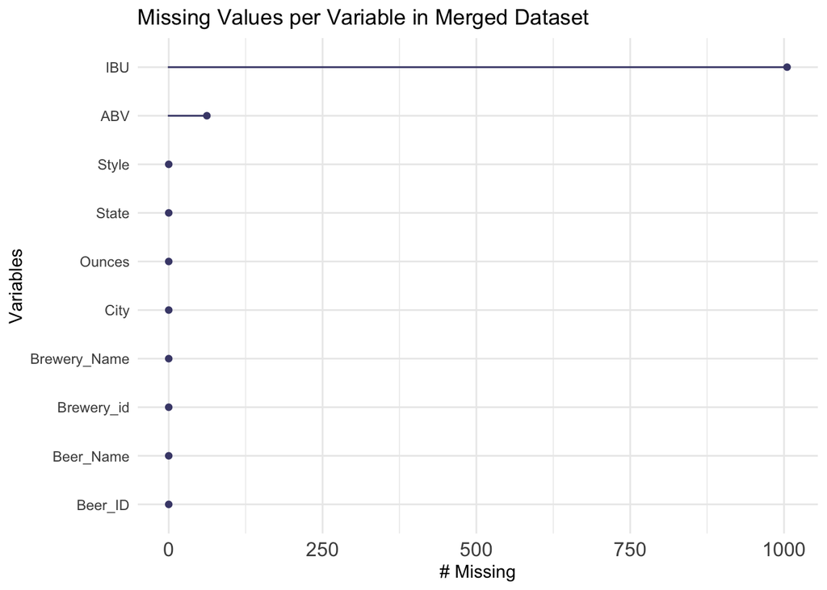

```r
gg_miss_var(beers_merge) + ggtitle("Missing Values per Variable in Merged Dataset") + theme(axis.text.x=element_text(size= 12))
```

#### The brewries data frame has no NA values but the beers data frame has 1067 NA values. When the two tables are merged together, the 1067 NA values from the beers data frame are transferred to the beers_merge data frame. There are 1005 NA values in IBU and 62 NA values in ABV.

## Compute the median alcohol content and international bitterness unit for each state. Plot a bar chart to compare

```r
#Create summarized data frame with ABV and IBU medians
ABV_IBU_by_state = data.frame(beers_merge %>% group_by(State) %>% summarise(median_ABV = median(ABV,na.rm = TRUE), median_IBU = median(IBU,na.rm = TRUE)))
```

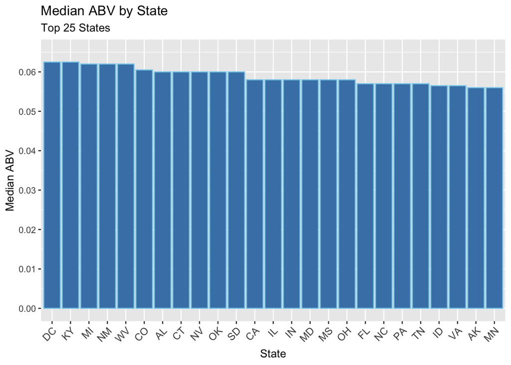

```r
#Re-order the factors for median_ABV so the bar chart can be plotted in descending order
ABV_IBU_by_state$State= fct_reorder(ABV_IBU_by_state$State, desc(ABV_IBU_by_state$median_ABV))

#Arrange the data frame where median_ABV is in descending order so that the data frame can be sliced
ABV_IBU_by_state = ABV_IBU_by_state %>% arrange(desc(median_ABV))

#Due to the plot being too cluttered when plotting all states at once, slice the data frame in half and make two bar charts
head(ABV_IBU_by_state,25) %>% ggplot(aes(x=State,y=median_ABV)) + geom_bar(stat = 'identity',color='skyblue',fill='steelblue') + xlab("State") + ylab("Median ABV") + ggtitle("Median ABV by State","Top 25 States") + theme(axis.text.x=element_text(size= 10, angle=45, hjust=1)) + scale_y_continuous(breaks = seq(0,0.07,0.01),limits = c(0,0.065))
```

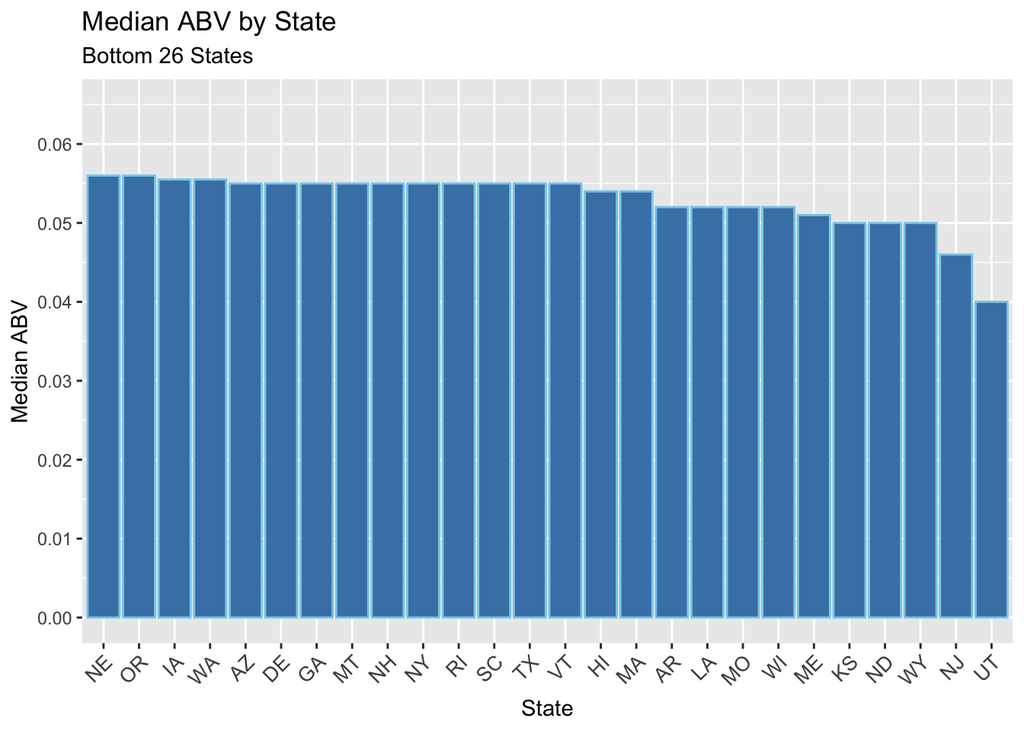

```r
tail(ABV_IBU_by_state,26) %>% ggplot(aes(x=State,y=median_ABV)) + geom_bar(stat = 'identity',color='skyblue',fill='steelblue') + xlab("State") + ylab("Median ABV") + ggtitle("Median ABV by State","Bottom 26 States") + theme(axis.text.x=element_text(size= 10, angle=45, hjust=1)) + scale_y_continuous(breaks = seq(0,0.06,0.01),limits = c(0,0.065))
```

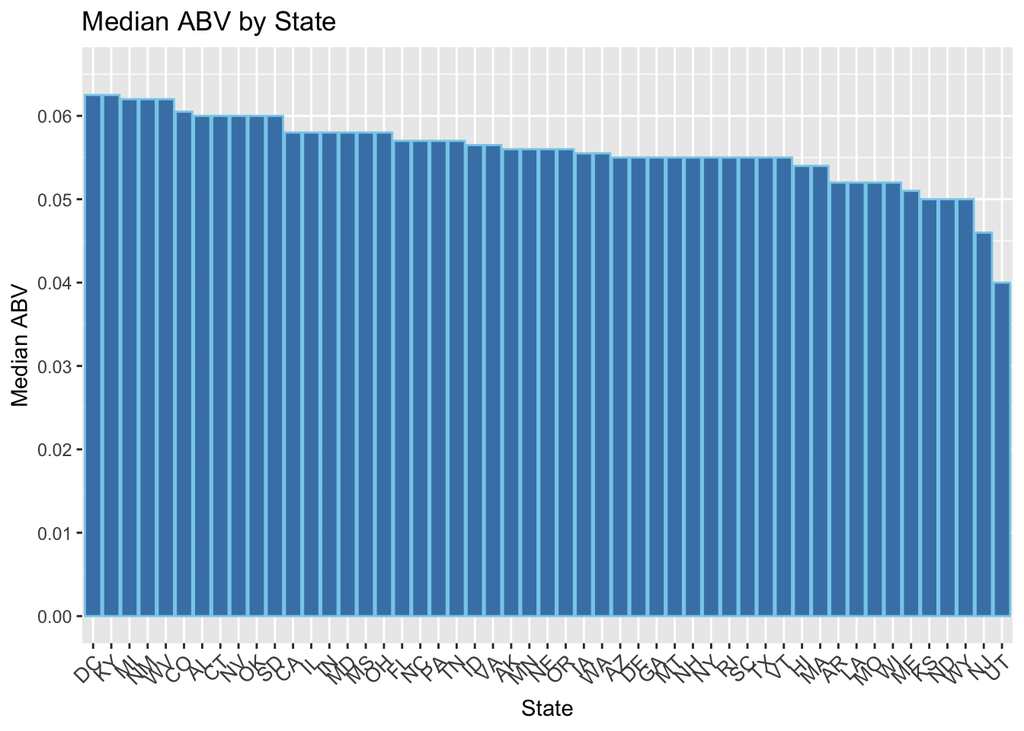

```r
#Adding combined chart of all 51 states (doesn't output in knit file well)
ABV_IBU_by_state %>% ggplot(aes(x=State,y=median_ABV)) + geom_bar(stat = 'identity',color='skyblue',fill='steelblue') + xlab("State") + ylab("Median ABV") + ggtitle("Median ABV by State") + theme(axis.text.x=element_text(size= 10, angle=45, hjust=1)) + scale_y_continuous(breaks = seq(0,0.07,0.01),limits = c(0,0.065))
```

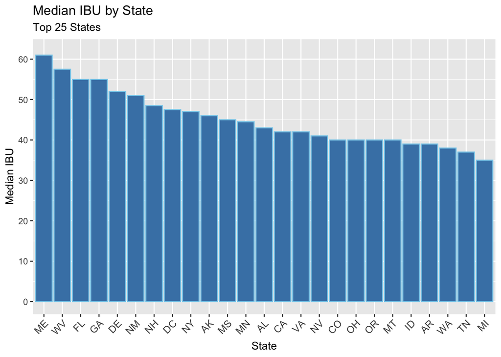

```r
#Repeat steps above to plot median_IBU
ABV_IBU_by_state$State= fct_reorder(ABV_IBU_by_state$State, desc(ABV_IBU_by_state$median_IBU))

ABV_IBU_by_state = ABV_IBU_by_state %>% arrange(desc(median_IBU))

head(ABV_IBU_by_state,25) %>% ggplot(aes(x=State,y=median_IBU)) + geom_bar(stat = 'identity',color='skyblue',fill='steelblue') + xlab("State") + ylab("Median IBU") + ggtitle("Median IBU by State","Top 25 States") + theme(axis.text.x=element_text(size= 10, angle=45, hjust=1)) + scale_y_continuous(breaks = seq(0,65,10),limits = c(0,62))
```

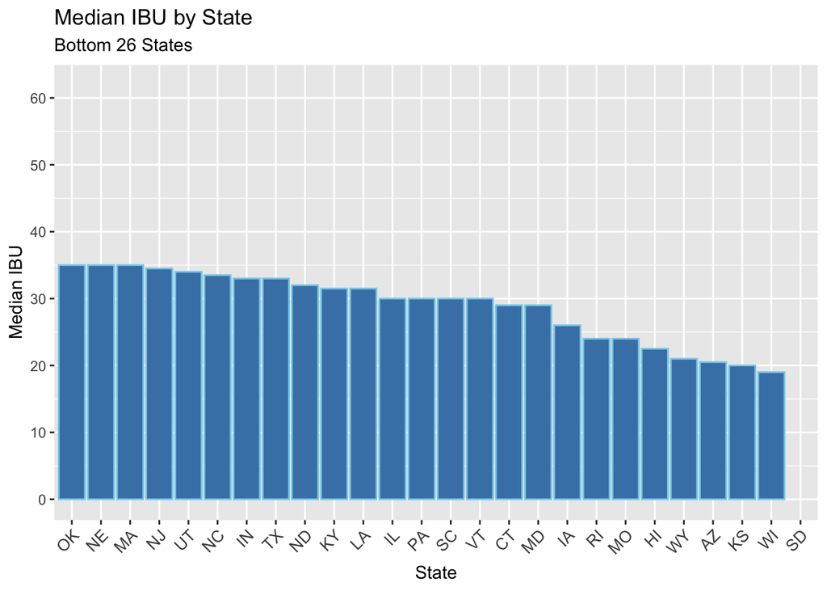

```r
tail(ABV_IBU_by_state,26) %>% ggplot(aes(x=State,y=median_IBU)) + geom_bar(stat = 'identity',color='skyblue',fill='steelblue') + xlab("State") + ylab("Median IBU") + ggtitle("Median IBU by State","Bottom 26 States") + theme(axis.text.x=element_text(size= 10, angle=45, hjust=1)) + scale_y_continuous(breaks = seq(0,65,10),limits = c(0,62))
```

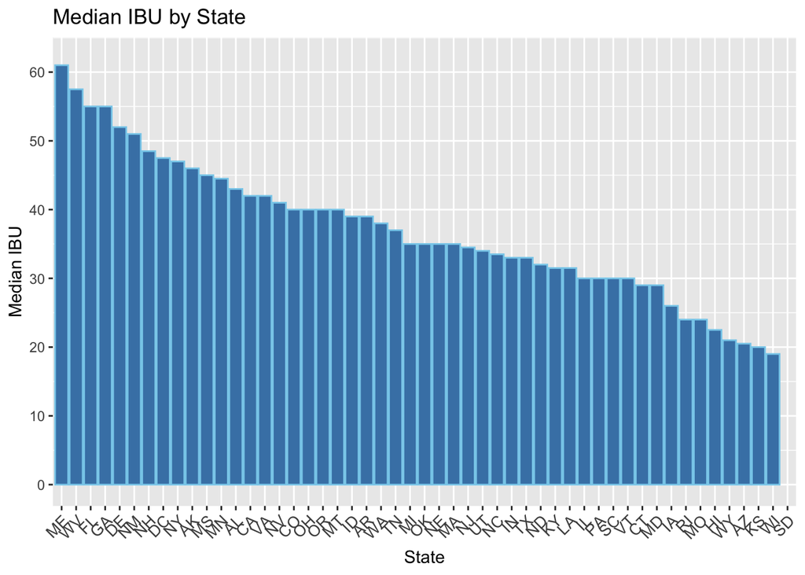

```r
#Adding combined chart of all 51 states (doesn't output in knit file well)
ABV_IBU_by_state %>% ggplot(aes(x=State,y=median_IBU)) + geom_bar(stat = 'identity',color='skyblue',fill='steelblue') + xlab("State") + ylab("Median IBU") + ggtitle("Median IBU by State") + theme(axis.text.x=element_text(size= 10, angle=45, hjust=1)) + scale_y_continuous(breaks = seq(0,65,10),limits = c(0,62))
```

## Which state has the maximum alcoholic (ABV) beer? Which state has the most bitter (IBU) beer?

```r
#Max IBU beer
beers_merge[which(beers_merge$IBU==max(beers_merge$IBU,na.rm = TRUE)),]
```

```
##      Brewery_id                 Beer_Name Beer_ID   ABV IBU
## 1479        375 Bitter Bitch Imperial IPA     980 0.082 138
##                               Style Ounces            Brewery_Name    City
## 1479 American Double / Imperial IPA     12 Astoria Brewing Company Astoria
##      State
## 1479    OR
```

```r
#Max ABV beer
beers_merge[which(beers_merge$ABV==max(beers_merge$ABV,na.rm = TRUE)),]
```

```
##      Brewery_id                                            Beer_Name Beer_ID
## 2048         52 Lee Hill Series Vol. 5 - Belgian Style Quadrupel Ale    2565
##        ABV IBU            Style Ounces            Brewery_Name    City State
## 2048 0.128  NA Quadrupel (Quad)   19.2 Upslope Brewing Company Boulder    CO
```

## Comment on the summary statistics and distribution of the ABV variable.

```r
summary(beers_merge$ABV)
```

```
##    Min. 1st Qu.  Median    Mean 3rd Qu.    Max.    NA's
## 0.00100 0.05000 0.05600 0.05977 0.06700 0.12800      62
```

```r
#Looking at beers between 9% and 10% ABV
dim(beers_merge[beers_merge$ABV<.1 & (beers_merge$ABV>.09 & !is.na(beers_merge$ABV)),])
```

```
## [1] 79 10
```

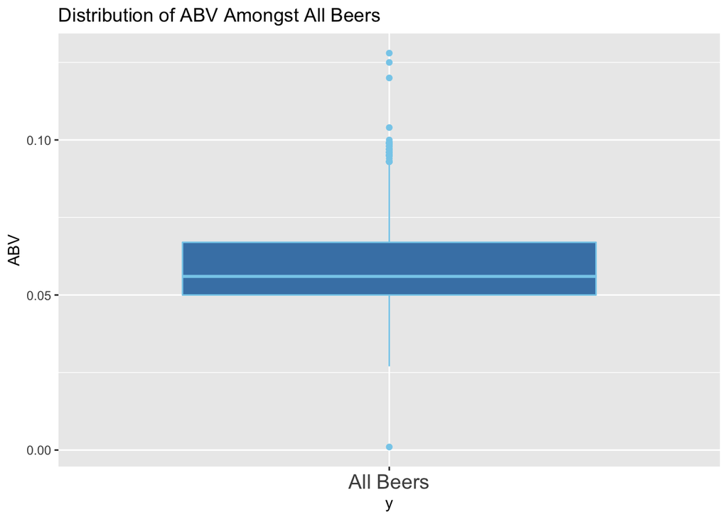

```r
#Plotting ABV Distribution
beers_merge %>% ggplot() + geom_boxplot(aes(x=ABV,y="All Beers"), color='skyblue', fill='steelblue') + ggtitle("Distribution of ABV Amongst All Beers") + coord_flip() + theme(axis.text.x=element_text(size= 14, hjust=.5))
```

## Is there an apparent relationship between the bitterness of the beer and its alcoholic content? Draw a scatter plot. Make your best judgment of a relationship and EXPLAIN your answer.

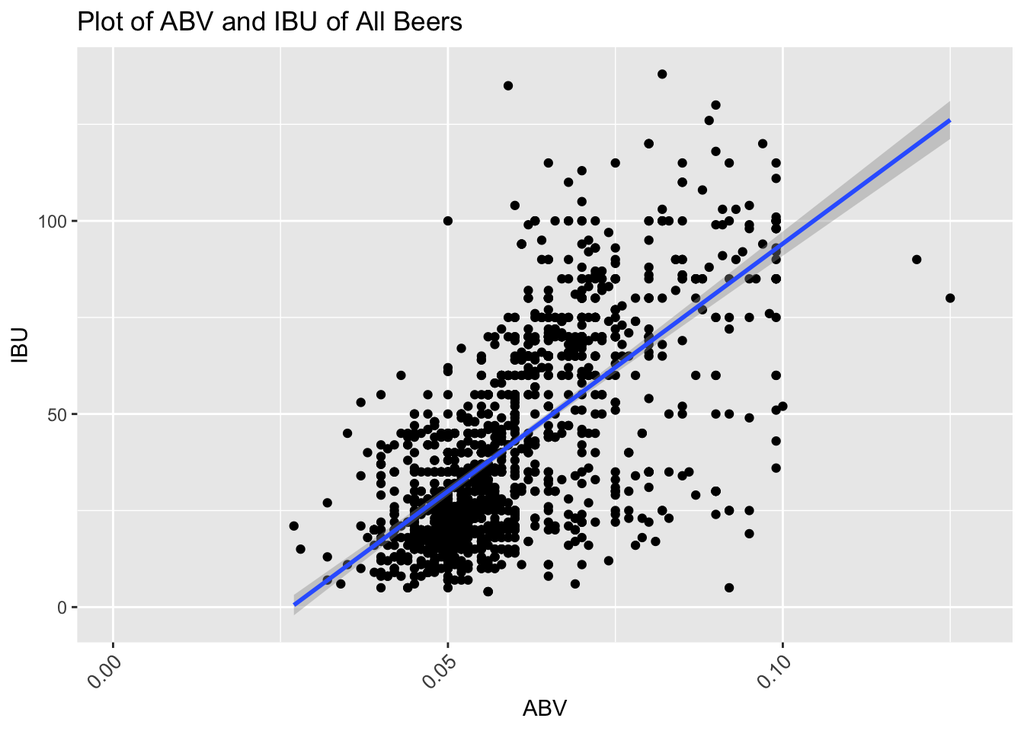

```r
beers_merge %>% ggplot(aes(x=ABV,y=IBU)) + geom_point() + geom_smooth(method = "lm") + ggtitle("Plot of ABV and IBU of All Beers") + theme(axis.text.x=element_text(size= 10, angle=45, hjust=1))
```

```r
#Linear model data (such as R-Squared)
summary(lm(IBU~ABV,data = beers_merge))
```

```
##
## Call:
## lm(formula = IBU ~ ABV, data = beers_merge)
##
## Residuals:
##     Min      1Q  Median      3Q     Max
## -78.849 -11.977  -0.721  13.997  93.458
##
## Coefficients:
##             Estimate Std. Error t value Pr(>|t|)
## (Intercept)  -34.099      2.326  -14.66   <2e-16 ***
## ABV         1282.037     37.860   33.86   <2e-16 ***
## ---
## Signif. codes:  0 '***' 0.001 '**' 0.01 '*' 0.05 '.' 0.1 ' ' 1
##
## Residual standard error: 19.26 on 1403 degrees of freedom
##   (1005 observations deleted due to missingness)
## Multiple R-squared:  0.4497, Adjusted R-squared:  0.4493
## F-statistic:  1147 on 1 and 1403 DF,  p-value: < 2.2e-16
```

## Budweiser would also like to investigate the difference with respect to IBU and ABV between IPAs (India Pale Ales) and other types of Ale (any beer with “Ale” in its name other than IPA). You decide to use KNN classification to investigate this relationship. Provide statistical evidence one way or the other. You can of course assume your audience is comfortable with percentages … KNN is very easy to understand conceptually.

## In addition, while you have decided to use KNN to investigate this relationship (KNN is required) you may also feel free to supplement your response to this question with any other methods or techniques you have learned. Creativity and alternative solutions are always encouraged.

```r
#Convert all blank Styles to NA so they will be removed during cleaning
beers_merge[beers_merge==""]=NA #You can also do then when loading in the data

#Check dim of beers_merge and then check how many rows don't have any NAs
dim(beers_merge)
```

```
## [1] 2410   10
```

```r
sum(complete.cases(beers_merge))
```

```
## [1] 1403
```

```r
#Clean the dataset and verify dim of cleaned data
beers_merge_clean = na.omit(beers_merge)

#Reset row names after cleaning
beers_merge_clean[214,] #Example of why they need to be cleaned
```

```
##     Brewery_id               Beer_Name Beer_ID   ABV IBU        Style Ounces
## 378        156 Hopportunity Knocks IPA    2315 0.068 100 American IPA     12
##                Brewery_Name    City State
## 378 Caldera Brewing Company Ashland    OR
```

```r
row.names(beers_merge_clean) = 1:dim(beers_merge_clean)[1]
beers_merge_clean[214,]
```

```
##     Brewery_id               Beer_Name Beer_ID   ABV IBU        Style Ounces
## 214        156 Hopportunity Knocks IPA    2315 0.068 100 American IPA     12
##                Brewery_Name    City State
## 214 Caldera Brewing Company Ashland    OR
```

```r
#Reset factor levels of Style (because we removed blanks and NAs)
beers_merge_clean$Style = factor(beers_merge_clean$Style)

##Filter dataset to include only Ales and divide between IPA and non-IPA Ale
beers_merge_ale = beers_merge_clean[grep(x = beers_merge_clean$Style,pattern = '(\\bIPA\\b|\\bAle\\b)',ignore.case = TRUE),]
beers_merge_ale$IPA_or_Other_Ale = beers_merge_ale$Style
beers_merge_ale$IPA_or_Other_Ale = as.character(beers_merge_ale$IPA_or_Other_Ale)
beers_merge_ale$IPA_or_Other_Ale[grepl(x = beers_merge_ale$IPA_or_Other_Ale,pattern = '(\\bIPA\\b)',ignore.case = TRUE)]="IPA"
beers_merge_ale$IPA_or_Other_Ale[grep(x = beers_merge_ale$IPA_or_Other_Ale,pattern = '(\\bAle\\b)',ignore.case = TRUE)]="Other_Ale"
beers_merge_ale$IPA_or_Other_Ale = factor(beers_merge_ale$IPA_or_Other_Ale)

#Standardize values of input variables
beers_merge_ale$Z_ABV = scale(beers_merge_ale$ABV)
beers_merge_ale$Z_IBU = scale(beers_merge_ale$IBU)

#Repeat but with internal cross validation (we run multiple samples because of ties)
str(beers_merge_ale)
```

```
## 'data.frame':    944 obs. of  13 variables:
##  $ Brewery_id      : Factor w/ 558 levels "1","2","3","4",..: 1 1 1 100 102 102 102 103 104 104 ...
##  $ Beer_Name       : chr  "Get Together" "Wall's End" "Pumpion" "Bay of Bengal Double IPA (2014)" ...
##  $ Beer_ID         : Factor w/ 2410 levels "1","4","5","6",..: 2410 2408 2407 2161 2158 549 110 1412 2144 2141 ...
##  $ ABV             : num  0.045 0.048 0.06 0.089 0.065 0.052 0.052 0.06 0.058 0.068 ...
##  $ IBU             : int  50 19 38 126 75 24 24 70 45 85 ...
##  $ Style           : Factor w/ 90 levels "Abbey Single Ale",..: 15 44 75 11 15 4 4 15 16 15 ...
##  $ Ounces          : num  16 16 16 12 12 12 12 12 12 12 ...
##  $ Brewery_Name    : chr  "NorthGate Brewing " "NorthGate Brewing " "NorthGate Brewing " "Christian Moerlein Brewing Company" ...
##  $ City            : Factor w/ 384 levels "Abingdon","Abita Springs",..: 228 228 228 71 251 251 251 8 202 202 ...
##  $ State           : Factor w/ 51 levels " AK"," AL"," AR",..: 24 24 24 36 40 40 40 1 20 20 ...
##  $ IPA_or_Other_Ale: Factor w/ 2 levels "IPA","Other_Ale": 1 2 2 1 1 2 2 1 2 1 ...
##  $ Z_ABV           : num [1:944, 1] -1.279 -1.051 -0.136 2.074 0.245 ...
##   ..- attr(*, "scaled:center")= num 0.0618
##   ..- attr(*, "scaled:scale")= num 0.0131
##  $ Z_IBU           : num [1:944, 1] 0.00177 -1.17742 -0.45469 2.89269 0.95273 ...
##   ..- attr(*, "scaled:center")= num 50
##   ..- attr(*, "scaled:scale")= num 26.3
##  - attr(*, "na.action")= 'omit' Named int [1:1007] 7 9 10 11 12 17 18 21 27 37 ...
##   ..- attr(*, "names")= chr [1:1007] "7" "9" "10" "11" ...
```

```r
train_cols = beers_merge_ale[,12:13]
outcome_data = beers_merge_ale[,11]
num_rand_samples = 15
max_k = 55
accuracy_matrix = matrix(nrow = num_rand_samples,ncol = max_k)

for(i in 1:num_rand_samples)
{
  for(j in 1:max_k)
  {
    class_data = knn.cv(train_cols,cl = outcome_data,k=j)
    CM = confusionMatrix(table(class_data,outcome_data))
    accuracy_matrix[i,j] = CM$overall[1]
  }
}

MeanAcc = colMeans(accuracy_matrix)
which(MeanAcc==max(MeanAcc))
```

```
## [1] 23
```

```r
max(MeanAcc)
```

```
## [1] 0.8680791
```

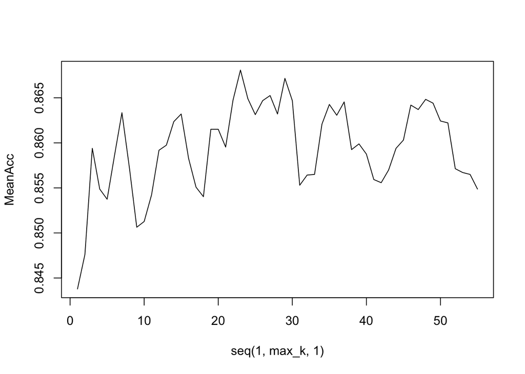

```r
plot(seq(1,max_k,1),MeanAcc, type = "l")
```

#Find another insight

```r
##Filter dataset to include only Ales and divide between IPA and non-IPA Ale
beer_style_breakdown = data.frame(beers_merge_clean %>% group_by(Style) %>% summarise(Count = n(), ABV_median=median(ABV), IBU_median=median(IBU)) %>% arrange(desc(Count)))
beers_merge_simplified_style = beers_merge_clean
str(beers_merge_clean$Style)
```

```
##  Factor w/ 90 levels "Abbey Single Ale",..: 15 69 44 75 20 53 11 65 15 4 ...
```

```r
levels(beers_merge_clean$Style)
```

```
##  [1] "Abbey Single Ale"                    "Altbier"
##  [3] "American Adjunct Lager"              "American Amber / Red Ale"
##  [5] "American Amber / Red Lager"          "American Barleywine"
##  [7] "American Black Ale"                  "American Blonde Ale"
##  [9] "American Brown Ale"                  "American Dark Wheat Ale"
## [11] "American Double / Imperial IPA"      "American Double / Imperial Pilsner"
## [13] "American Double / Imperial Stout"    "American India Pale Lager"
## [15] "American IPA"                        "American Pale Ale (APA)"
## [17] "American Pale Lager"                 "American Pale Wheat Ale"
## [19] "American Pilsner"                    "American Porter"
## [21] "American Stout"                      "American Strong Ale"
## [23] "American White IPA"                  "American Wild Ale"
## [25] "Baltic Porter"                       "Belgian Dark Ale"
## [27] "Belgian IPA"                         "Belgian Pale Ale"
## [29] "Belgian Strong Dark Ale"             "Belgian Strong Pale Ale"
```

[output cut: 30 more lines]

```r
beers_merge_simplified_style$type = beers_merge_simplified_style$Style
beers_merge_simplified_style$type = as.character(beers_merge_simplified_style$type)
beers_merge_simplified_style$type[grepl(x = beers_merge_simplified_style$type,pattern = '(\\bIPA\\b)',ignore.case = TRUE)]="IPA "

beer_style_breakdown2 = data.frame(beers_merge_simplified_style %>% group_by(type) %>% summarise(Count = n(), ABV_median=median(ABV), IBU_median=median(IBU)) %>% arrange(desc(Count)))
beer_style_breakdown2
```

```
##                                   type Count ABV_median IBU_median
## 1                                 IPA    392     0.0680       70.0
## 2              American Pale Ale (APA)   153     0.0550       44.0
## 3             American Amber / Red Ale    77     0.0560       31.0
## 4                  American Blonde Ale    61     0.0500       20.0
## 5              American Pale Wheat Ale    61     0.0480       20.0
## 6                      American Porter    39     0.0580       31.0
## 7                   American Brown Ale    38     0.0550       26.0
## 8               Fruit / Vegetable Beer    30     0.0505       15.5
## 9                           Hefeweizen    27     0.0510       15.0
## 10                              Kölsch    27     0.0490       22.0
## 11                             Witbier    24     0.0500       15.5
## 12              Saison / Farmhouse Ale    23     0.0580       30.0
## 13                Märzen / Oktoberfest    21     0.0560       23.0
## 14                  American Black Ale    20     0.0720       73.0
```

[output cut: 72 more lines]

```r
beers_merge_simplified_style$type[grepl(x = beers_merge_simplified_style$type,pattern = '(\\bLager\\b)',ignore.case = TRUE)]="Lager "

beer_style_breakdown3 = data.frame(beers_merge_simplified_style %>% group_by(type) %>% summarise(Count = n(), ABV_median=median(ABV), IBU_median=median(IBU)) %>% arrange(desc(Count)))
beer_style_breakdown3
```

```
##                                   type Count ABV_median IBU_median
## 1                                 IPA    392     0.0680       70.0
## 2              American Pale Ale (APA)   153     0.0550       44.0
## 3                               Lager     88     0.0490       19.0
## 4             American Amber / Red Ale    77     0.0560       31.0
## 5                  American Blonde Ale    61     0.0500       20.0
## 6              American Pale Wheat Ale    61     0.0480       20.0
## 7                      American Porter    39     0.0580       31.0
## 8                   American Brown Ale    38     0.0550       26.0
## 9               Fruit / Vegetable Beer    30     0.0505       15.5
## 10                          Hefeweizen    27     0.0510       15.0
## 11                              Kölsch    27     0.0490       22.0
## 12                             Witbier    24     0.0500       15.5
## 13              Saison / Farmhouse Ale    23     0.0580       30.0
## 14                Märzen / Oktoberfest    21     0.0560       23.0
```

[output cut: 62 more lines]

```r
beers_merge_simplified_style$type[grep(x = beers_merge_simplified_style$type,pattern = '(\\bRed Ale\\b|\\bAmber Ale\\b)',ignore.case = TRUE)]="Red_or_Amber_Ale "

beer_style_breakdown4 = data.frame(beers_merge_simplified_style %>% group_by(type) %>% summarise(Count = n(), ABV_median=median(ABV), IBU_median=median(IBU)) %>% arrange(desc(Count)))
beer_style_breakdown4
```

```
##                                   type Count ABV_median IBU_median
## 1                                 IPA    392     0.0680       70.0
## 2              American Pale Ale (APA)   153     0.0550       44.0
## 3                               Lager     88     0.0490       19.0
## 4                    Red_or_Amber_Ale     85     0.0550       30.0
## 5                  American Blonde Ale    61     0.0500       20.0
## 6              American Pale Wheat Ale    61     0.0480       20.0
## 7                      American Porter    39     0.0580       31.0
## 8                   American Brown Ale    38     0.0550       26.0
## 9               Fruit / Vegetable Beer    30     0.0505       15.5
## 10                          Hefeweizen    27     0.0510       15.0
## 11                              Kölsch    27     0.0490       22.0
## 12                             Witbier    24     0.0500       15.5
## 13              Saison / Farmhouse Ale    23     0.0580       30.0
## 14                Märzen / Oktoberfest    21     0.0560       23.0
```

[output cut: 61 more lines]

```r
beers_merge_simplified_style$type[grep(x = beers_merge_simplified_style$type,pattern = '(\\bPale\\b)',ignore.case = TRUE)]="Pale Ale "

beer_style_breakdown5 = data.frame(beers_merge_simplified_style %>% group_by(type) %>% summarise(Count = n(), ABV_median=median(ABV), IBU_median=median(IBU)) %>% arrange(desc(Count)))
beer_style_breakdown5
```

```
##                                   type Count ABV_median IBU_median
## 1                                 IPA    392     0.0680       70.0
## 2                            Pale Ale    230     0.0530       37.0
## 3                               Lager     88     0.0490       19.0
## 4                    Red_or_Amber_Ale     85     0.0550       30.0
## 5                  American Blonde Ale    61     0.0500       20.0
## 6                      American Porter    39     0.0580       31.0
## 7                   American Brown Ale    38     0.0550       26.0
## 8               Fruit / Vegetable Beer    30     0.0505       15.5
## 9                           Hefeweizen    27     0.0510       15.0
## 10                              Kölsch    27     0.0490       22.0
## 11                             Witbier    24     0.0500       15.5
## 12              Saison / Farmhouse Ale    23     0.0580       30.0
## 13                Märzen / Oktoberfest    21     0.0560       23.0
## 14                  American Black Ale    20     0.0720       73.0
```

[output cut: 56 more lines]

```r
beers_merge_simplified_style$type[grep(x = beers_merge_simplified_style$type,pattern = '(\\bStout\\b)',ignore.case = TRUE)]="Stout "

beer_style_breakdown6 = data.frame(beers_merge_simplified_style %>% group_by(type) %>% summarise(Count = n(), ABV_median=median(ABV), IBU_median=median(IBU)) %>% arrange(desc(Count)))
beer_style_breakdown6
```

```
##                                   type Count ABV_median IBU_median
## 1                                 IPA    392     0.0680       70.0
## 2                            Pale Ale    230     0.0530       37.0
## 3                               Lager     88     0.0490       19.0
## 4                    Red_or_Amber_Ale     85     0.0550       30.0
## 5                  American Blonde Ale    61     0.0500       20.0
## 6                               Stout     51     0.0600       38.0
## 7                      American Porter    39     0.0580       31.0
## 8                   American Brown Ale    38     0.0550       26.0
## 9               Fruit / Vegetable Beer    30     0.0505       15.5
## 10                          Hefeweizen    27     0.0510       15.0
## 11                              Kölsch    27     0.0490       22.0
## 12                             Witbier    24     0.0500       15.5
## 13              Saison / Farmhouse Ale    23     0.0580       30.0
## 14                Märzen / Oktoberfest    21     0.0560       23.0
```

[output cut: 49 more lines]

```r
beers_merge_simplified_style$type[grep(x = beers_merge_simplified_style$type,pattern = '(\\bPilsner\\b|\\bPilsener\\b)',ignore.case = TRUE)]="Pilsner "

beer_style_breakdown7 = data.frame(beers_merge_simplified_style %>% group_by(type) %>% summarise(Count = n(), ABV_median=median(ABV), IBU_median=median(IBU)) %>% arrange(desc(Count)))
beer_style_breakdown7
```

```
##                                   type Count ABV_median IBU_median
## 1                                 IPA    392     0.0680       70.0
## 2                            Pale Ale    230     0.0530       37.0
## 3                               Lager     88     0.0490       19.0
## 4                    Red_or_Amber_Ale     85     0.0550       30.0
## 5                  American Blonde Ale    61     0.0500       20.0
## 6                               Stout     51     0.0600       38.0
## 7                             Pilsner     48     0.0505       32.0
## 8                      American Porter    39     0.0580       31.0
## 9                   American Brown Ale    38     0.0550       26.0
## 10              Fruit / Vegetable Beer    30     0.0505       15.5
## 11                          Hefeweizen    27     0.0510       15.0
## 12                              Kölsch    27     0.0490       22.0
## 13                             Witbier    24     0.0500       15.5
## 14              Saison / Farmhouse Ale    23     0.0580       30.0
```

[output cut: 46 more lines]